# Kravd innlating 3 (required lab 3)

Hans Kári Joensen, Ragnar Winther

To be handed in on 10. october 2018 in Moodle. Name your document kravd3_5021_NN1_NN2.nb.html with your names for NN1 and NN2.

## Data Science and statistics with RStudio

### Introduction

> Similar requirements as for the first and second required assignment (see the previous exercises).

```r
# Put your answers to code-based questions into the given empty code-blocks.
# Run (test) your individual code chunks (Ctrl + Shift + Enter).
# Run All code blocks (Ctrl + Alt + R) before you "Preview" (Ctrl + Shift + K) the notebook in a browser.
```

```
By starting a text-line with 4 empty spaces, format your text-based answers into a box right below such questions.
```

> When finished, run all code blocks (Ctrl + Alt + R) and make a final “Preview” (Ctrl + Shift + K), to be opened in a browser and hand in the document: “kravd3_5021_NN1_NN2.nb.html”.

### Load packages

> In this exercise, you will need to load the packages: `tidyverse`, `knitr`, `broom`, `lubridate`, `gapminder`.

```r
library(tidyverse)
library(knitr)
library(broom)
library(lubridate)
library(gapminder)
```

### Exercise 1

> 1. show the output of `gapminder`.

```r
gapminder
```

| country | continent | year | lifeExp | pop | gdpPercap |
| --- | --- | --- | --- | --- | --- |
| Afghanistan | Asia | 1952 | 28.80100 | 8425333 | 779.4453 |
| Afghanistan | Asia | 1957 | 30.33200 | 9240934 | 820.8530 |
| Afghanistan | Asia | 1962 | 31.99700 | 10267083 | 853.1007 |
| Afghanistan | Asia | 1967 | 34.02000 | 11537966 | 836.1971 |
| Afghanistan | Asia | 1972 | 36.08800 | 13079460 | 739.9811 |
| Afghanistan | Asia | 1977 | 38.43800 | 14880372 | 786.1134 |
| Afghanistan | Asia | 1982 | 39.85400 | 12881816 | 978.0114 |
| Afghanistan | Asia | 1987 | 40.82200 | 13867957 | 852.3959 |
| Afghanistan | Asia | 1992 | 41.67400 | 16317921 | 649.3414 |
| Afghanistan | Asia | 1997 | 41.76300 | 22227415 | 635.3414 |

[output cut: 990 more lines]

> 2. investigate the structure `str()` of `gapminder`:
> - is it a tibble?
> - how many levels are there in the factor variables `country` and `continent`?

```r
str(gapminder)
```

```
Classes ‘tbl_df’, ‘tbl’ and 'data.frame':   1704 obs. of  6 variables:
 $ country  : Factor w/ 142 levels "Afghanistan",..: 1 1 1 1 1 1 1 1 1 1 ...
 $ continent: Factor w/ 5 levels "Africa","Americas",..: 3 3 3 3 3 3 3 3 3 3 ...
 $ year     : int  1952 1957 1962 1967 1972 1977 1982 1987 1992 1997 ...
 $ lifeExp  : num  28.8 30.3 32 34 36.1 ...
 $ pop      : int  8425333 9240934 10267083 11537966 13079460 14880372 12881816 13867957 16317921 22227415 ...
 $ gdpPercap: num  779 821 853 836 740 ...
```

```
Gapminder is a tibble data frame.
Country has 142 levels and continent has 5 levels
```

> 3. use `distinct()` to show the distinct values of the variable `country`.

```r
n_distinct(gapminder$country)
```

```
[1] 142
```

> 4. use a pipe of `gapminder` to show the distinct countries sorted by the continents. Your results should include the two variables `country` and `continent` with 142 rows of observations.

```r
gapminder %>%
  group_by(continent) %>%
  distinct(country) %>%
  arrange(continent)
```

| country | continent |
| --- | --- |
| Algeria | Africa |
| Angola | Africa |
| Benin | Africa |
| Botswana | Africa |
| Burkina Faso | Africa |
| Burundi | Africa |
| Cameroon | Africa |
| Central African Republic | Africa |
| Chad | Africa |
| Comoros | Africa |

[output cut: 132 more lines]

> 5. use a pipe to summarise how many distinct `country, year` and number of observations `n` there are for each continent. Your result should include the variables `continent, countries, years` and `n` with five rows of summarised statistics - one row for each continent.

```r
gapminder %>%
  group_by(continent) %>%
  summarise(years = n_distinct(year), countries = n_distinct(country), n = n())
```

| continent | years | countries | n |
| --- | --- | --- | --- |
| Africa | 12 | 52 | 624 |
| Americas | 12 | 25 | 300 |
| Asia | 12 | 33 | 396 |
| Europe | 12 | 30 | 360 |
| Oceania | 12 | 2 | 24 |

> 6. make a histogram of the life expectance `lifeExp` using `binwidt = 5` with a facet for each continent.

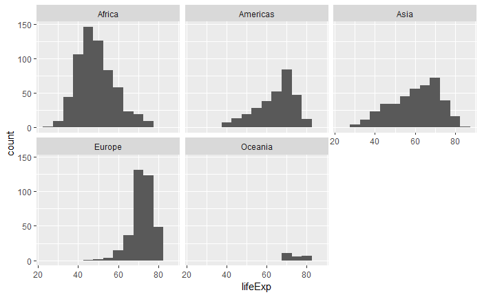

```r
ggplot(gapminder)+
  geom_histogram(mapping = aes(x = lifeExp), binwidth = 5)+
  facet_wrap(~continent)
```

### Exercise 2:

> 1. make a pipe of `gapminder` to summarise the number `n` of observations and to compute for variable `lifeExp`: the `min`, `q1`, `median`, `q3`, `max`, `IQR`, `mean` and `sd`. Your result should be 10 columns of variables (`continent`, `n`, `min`, `q1`, `median`, `q3`, `max`, `IQR`, `mean`, `sd`) with five rows of summarised statistics - one row for each continent (tip: you can either use `summarise` or `summarise_at` in your pipe).

```r
gapminder %>%
  group_by(continent) %>%
  summarise(n = n(), min = min(lifeExp), q1 = quantile(lifeExp, 0.25), median = median(lifeExp), q3 = quantile(lifeExp, 0.75), max = max(lifeExp), IQR = IQR(lifeExp), mean = mean(lifeExp), sd = sd(lifeExp))
```

| continent | n | min | q1 | median | q3 | max | IQR | mean | sd |
| --- | --- | --- | --- | --- | --- | --- | --- | --- | --- |
| Africa | 624 | 23.599 | 42.37250 | 47.7920 | 54.41150 | 76.442 | 12.0390 | 48.86533 | 9.150210 |
| Americas | 300 | 37.579 | 58.41000 | 67.0480 | 71.69950 | 80.653 | 13.2895 | 64.65874 | 9.345088 |
| Asia | 396 | 28.801 | 51.42625 | 61.7915 | 69.50525 | 82.603 | 18.0790 | 60.06490 | 11.864532 |
| Europe | 360 | 43.585 | 69.57000 | 72.2410 | 75.45050 | 81.757 | 5.8805 | 71.90369 | 5.433178 |
| Oceania | 24 | 69.120 | 71.20500 | 73.6650 | 77.55250 | 81.235 | 6.3475 | 74.32621 | 3.795611 |

> 2. make a boxplot of the life expectance `lifeExp` in `gapminder` for each continent by using `x = continent` and `y = lifeExp`.

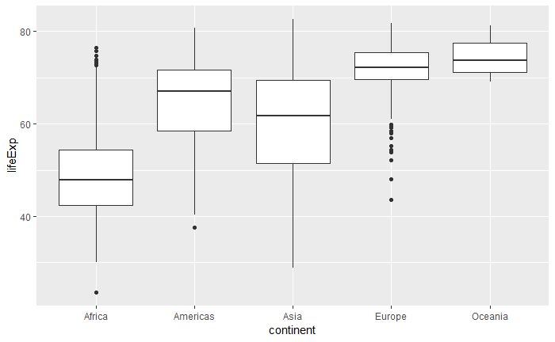

```r
ggplot(data = gapminder)+
  geom_boxplot(mapping = aes(x = continent, y = lifeExp))
```

> 3. modify the boxplot of `y = lifeExp` in `gapminder` by using `fct_reorder()`to modify the factor order of `x = continent` to correspond to increasing `lifeExp` (median) and label the x-axis “continent”.

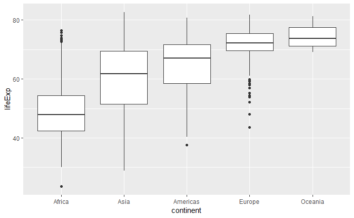

```r
ggplot(gapminder) +
  geom_boxplot(mapping = aes(fct_reorder(continent,lifeExp,median), y = lifeExp))+
  xlab("continent")
```

```r
NA
```

> 4. now only for the countries in “Americas”, make a boxplot of `x = country` and `y = lifeExp` in `gapminder` and again using `fct_reorder()`to modify the factor order of `x = country` to correspond to increasing `lifeExp` (median). Use `coord_flip()` to get the country names horizontal on the y-axsis that you label “country”.

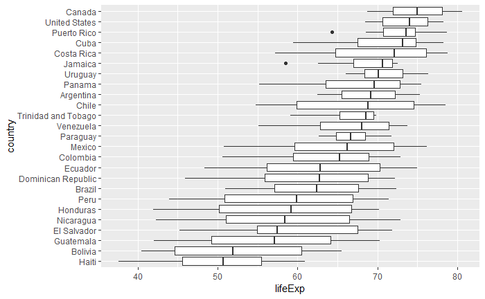

```r
americas <- gapminder %>%
  filter(continent == "Americas")
  ggplot(americas) +
  geom_boxplot(mapping = aes(fct_reorder(country, lifeExp, median), y = lifeExp))+
  xlab("country")+
  coord_flip()
```

> 5. now only for the countries in “Europe”, make a similar boxplot of `x = country` and `y = lifeExp` in `gapminder` and again using `fct_reorder()`to modify the factor order of `x = country` to correspond to increasing `lifeExp` (median). Use `coord_flip()` to get the country names horizontal on the y-axsis that you label “country”.

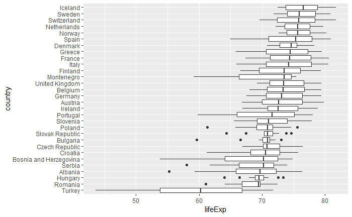

```r
europe <- gapminder %>%
  filter(continent == "Europe")
  ggplot(europe) +
  geom_boxplot(mapping = aes(fct_reorder(country, lifeExp, median), y = lifeExp))+
  xlab("country") +
  coord_flip()
```

> 6. now, only consider the nordic countries “Denmark”, “Finland”, “Iceland”, “Norway”, “Sweden”, together with “Ireland” and make a boxplot of `x = country` and `y = lifeExp` in `gapminder`still using `fct_reorder()`to modify the factor order of `x = country` to correspond to increasing `lifeExp` (median). Label the x-axsis “country”.

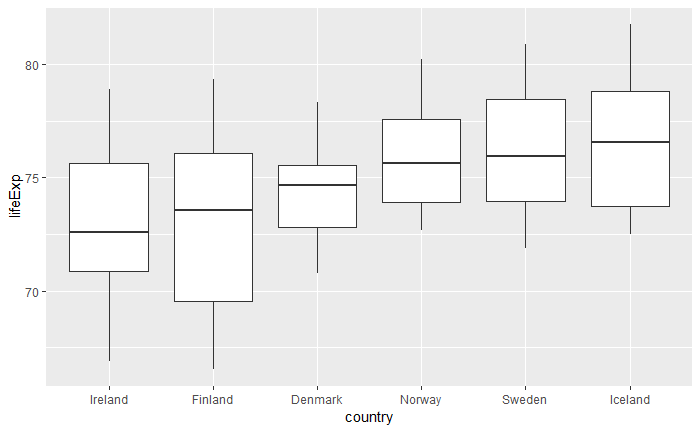

```r
nordic_list = c("Denmark", "Finland", "Iceland", "Norway", "Sweden", "Ireland")
nordic <- gapminder %>%
  filter(country %in% nordic_list)
ggplot(nordic) +
  geom_boxplot(mapping = aes(fct_reorder(country, lifeExp, median), y = lifeExp))+
  xlab("country")
```

### Exercise 3

> 1. make a pipe of `gapminder` to filter on the countries “Denmark”, “Finland”, “Iceland”, “Norway”, “Sweden”, “Ireland” and summarise for variable `lifeExp`: `n`, `min`, `q1`, `median`, `q3`, `max`, `IQR`, `mean`, `sd`. Your result should be 10 columns of variables (`country`, `n`, `min`, `q1`, `median`, `q3`, `max`, `IQR`, `mean`, `sd`) with six rows of summarised statistics - one row for each country (tip: you can either use `summarise` or `summarise_at` in your pipe).

```r
nordic_list = c("Denmark", "Finland", "Iceland", "Norway", "Sweden", "Ireland")
nordic <- gapminder %>%
  filter(country %in% nordic_list) %>%
  group_by(country) %>%
  summarise(n = n(), min = min(lifeExp), q1 = quantile(lifeExp, 0.25), median = median(lifeExp), q3 = quantile(lifeExp, 0.75), max = max(lifeExp), IQR = IQR(lifeExp), mean = mean(lifeExp), sd = sd(lifeExp))
nordic
```

| country | n | min | q1 | median | q3 | max | IQR | mean | sd |
| --- | --- | --- | --- | --- | --- | --- | --- | --- | --- |
| Denmark | 12 | 70.78 | 72.8075 | 74.660 | 75.52500 | 78.332 | 2.71750 | 74.37017 | 2.220111 |
| Finland | 12 | 66.55 | 69.5600 | 73.535 | 76.05750 | 79.313 | 6.49750 | 72.99192 | 4.302533 |
| Iceland | 12 | 72.49 | 73.7175 | 76.550 | 78.81500 | 81.757 | 5.09750 | 76.51142 | 3.026593 |
| Ireland | 12 | 66.91 | 70.8825 | 72.565 | 75.63075 | 78.885 | 4.74825 | 73.01725 | 3.618478 |
| Norway | 12 | 72.67 | 73.9275 | 75.630 | 77.57000 | 80.196 | 3.64250 | 75.84300 | 2.423994 |
| Sweden | 12 | 71.86 | 73.9625 | 75.930 | 78.46750 | 80.884 | 4.50500 | 76.17700 | 3.003990 |

> 2. again, consider the countries “Denmark”, “Finland”, “Iceland”, “Norway”, “Sweden”, “Ireland”. Make a qq-plot for the `lifeExp` data in `gapminder` using `stat_qq()` and also add lines using `stat_qq_line()`. Your plot should use `facet_wrap` by variable `country`.

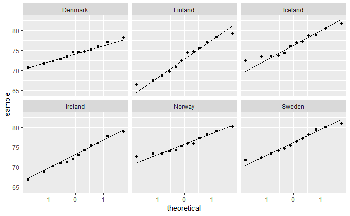

```r
nordic <- gapminder %>%
  filter(country %in% nordic_list)
ggplot(nordic, mapping = aes(sample = lifeExp)) +
  stat_qq() +
  stat_qq_line()+
  facet_wrap(~country)
```

> 3. considering the six: boxplots in 2f), rows in table 3a) and qq-plots in 3b), do you think these six distributions of `lifeExp` are: normal (symmetric), nearly-normal (slight/moderate skew) or far from the normal distribution (strong skew)?

```
According to the table in 3a, it is to say that the mean and median are close, and that indicates that
these distributions are normal.
In Denmark and Ireland, there might be a little bit of visible skew, according to the boxplots in 2f.
The qq-plots in 3b follow the line fairly well, while there is a little bit of systematic skew, where
the data deviates above from the line in the low range, and below from the line in the high range. This
is mostly the case in Finland, Iceland, Norway and Sweden. When drawing according conclusion according
to these factors, we conclude that these distributions are nearly-normal.
```

> 4. assuming independence of the observations in `gapminder` consider if the remaining conditions for using the two-sample `t.test()` are fulfilled for the variable `lifeExp` for the countries “Denmark” and “Ireland”. If ok, proceed to perform a two-sample `t.test()` in order to test if the sample means are equal for these two countries.

```
A condition for a two sample t.test which tests for differences in mean, is that each sample mean must
separately satisfy the one-sample conditions for the t.distribution, whereof one is that we can relax
the normal requirement with an increasing sample size. Slight skew is tolerated for a sample size of      15.
However, we only have a sample size of 12 for each country, as there is one sample of lifeExp pr year.
With a sample size this small, we should have little to no skew. The validity of the test is therefore
dependent upon the skew, but we will do a t.test on the data set
```

```r
denmark <- gapminder %>%
  filter(country %in% "Denmark")
ireland <- gapminder %>%
  filter(country %in% "Ireland")
t.test(denmark$lifeExp,ireland$lifeExp)
```

```
    Welch Two Sample t-test

data:  denmark$lifeExp and ireland$lifeExp
t = 1.104, df = 18.254, p-value = 0.2839
alternative hypothesis: true difference in means is not equal to 0
95 percent confidence interval:
 -1.219205  3.925038
sample estimates:
mean of x mean of y
 74.37017  73.01725
```

> - is the null hypothesis of the test rejected and why/why not? Because the p-value is higher than 0.05 the null hypothesis is not rejected
> 5. use `power.t.test()` to compute the power of the two sample `t.test()` in 3d) assuming a minimum effect size `delta = 3.15`, `sd = 3`, `sig.level = 0.05` and `n = 12` in each group.

```r
power.t.test(n = 12,delta = 3.15, sd = 3, sig.level = 0.05)
```

```
     Two-sample t test power calculation

              n = 12
          delta = 3.15
             sd = 3
      sig.level = 0.05
          power = 0.6909417
    alternative = two.sided

NOTE: n is number in *each* group
```

> 6. use `power.t.test()` to compute the sample size needed `n` in each group of the two sample `t.test()` assuming a minimum effect size `delta = 3.15`, `sd = 3`, `sig.level = 0.05` for `power = 0.7, 0.8`, and `0.9`, respectively.

```r
power.t.test(delta = 3.15, sd = 3, sig.level = 0.05, power = 0.7)
```

```
     Two-sample t test power calculation

              n = 12.23092
          delta = 3.15
             sd = 3
      sig.level = 0.05
          power = 0.7
    alternative = two.sided

NOTE: n is number in *each* group
```

```r
power.t.test(delta = 3.15, sd = 3, sig.level = 0.05, power = 0.8)
```

```
     Two-sample t test power calculation

              n = 15.26102
          delta = 3.15
             sd = 3
      sig.level = 0.05
          power = 0.8
    alternative = two.sided

NOTE: n is number in *each* group
```

```r
power.t.test(delta = 3.15, sd = 3, sig.level = 0.05, power = 0.9)
```

```
     Two-sample t test power calculation

              n = 20.07196
          delta = 3.15
             sd = 3
      sig.level = 0.05
          power = 0.9
    alternative = two.sided

NOTE: n is number in *each* group
```

> - repeat your calculations for the effect size `delta = 1`.

```r
power.t.test(delta = 1, sd = 3, sig.level = 0.05, power = 0.7)
```

```
     Two-sample t test power calculation

              n = 112.0652
          delta = 1
             sd = 3
      sig.level = 0.05
          power = 0.7
    alternative = two.sided

NOTE: n is number in *each* group
```

```r
power.t.test(delta = 1, sd = 3, sig.level = 0.05, power = 0.8)
```

```
     Two-sample t test power calculation

              n = 142.2466
          delta = 1
             sd = 3
      sig.level = 0.05
          power = 0.8
    alternative = two.sided

NOTE: n is number in *each* group
```

```r
power.t.test(delta = 1, sd = 3, sig.level = 0.05, power = 0.9)
```

```
     Two-sample t test power calculation

              n = 190.0991
          delta = 1
             sd = 3
      sig.level = 0.05
          power = 0.9
    alternative = two.sided

NOTE: n is number in *each* group
```

> - without making the two sample `t.test()` or a power calculation, do you think you can detect the difference betwenn the mean of variable `lifeExp` in `gapminder` for Norway and Sweden using the two sample `t.test()`, and explain why/why not?
> - now using `power.t.test()` estimate the probability that you can detect this difference.

### Exercise 4

> 1. create a scatterplot of `x = gdpPercap` and `y = lifeExp` in `gapminder_6`, that you create from the six countries: “Iceland”, “Sweden” , “Austria”, “Norway”, “Denmark”, “France” in `gapminder`. Also, add a best fit linear regression line `stat_smooth(method = lm)` (you get one linear model).

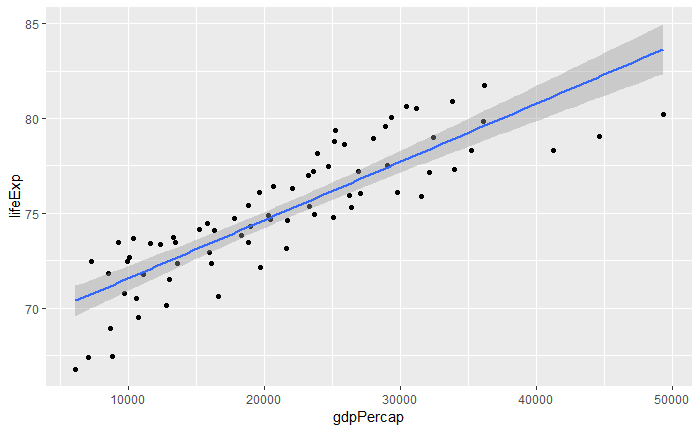

```r
countryfilter = c("Iceland", "Sweden" , "Austria", "Norway", "Denmark", "France")
gapminder_6 <- gapminder %>%
  filter(country %in% countryfilter)
ggplot(gapminder_6, mapping = aes(x = gdpPercap, y = lifeExp))+
  geom_point()+
  stat_smooth(method = lm)
```

> 2. run the code shown below to create a model object `mod` for the linear model and to output the model summary.

```r
mod <- lm(lifeExp ~ gdpPercap, data = gapminder_6)
summary(mod)
```

```
Call:
lm(formula = lifeExp ~ gdpPercap, data = gapminder_6)

Residuals:
    Min      1Q  Median      3Q     Max
-3.7437 -1.2040  0.1179  1.3598  3.1327

Coefficients:
             Estimate Std. Error t value Pr(>|t|)
(Intercept) 6.851e+01  5.175e-01  132.38   <2e-16 ***
gdpPercap   3.065e-04  2.213e-05   13.85   <2e-16 ***
---
Signif. codes:  0 ‘***’ 0.001 ‘**’ 0.01 ‘*’ 0.05 ‘.’ 0.1 ‘ ’ 1

Residual standard error: 1.79 on 70 degrees of freedom
Multiple R-squared:  0.7326,    Adjusted R-squared:  0.7288
F-statistic: 191.8 on 1 and 70 DF,  p-value: < 2.2e-16
```

> The “Residuals:” in the summary-output can be used as a fast check for the distribution assumption.
> - does the “Residuals:” section in this case indicate any problems? Explain your reasoning.
> - finally, show the quality-parameters of `mod` in a tidy format by using `broom::glance`.

```r
broom::glance(mod)
```

|  | r.squared | adj.r.squared | sigma | statistic | p.value | df | logLik | AIC | BIC | deviance | df.residual |
| --- | --- | --- | --- | --- | --- | --- | --- | --- | --- | --- | --- |
| 1 | 0.7326348 | 0.7288153 | 1.790198 | 191.8141 | 9.815081e-22 | 2 | -143.0769 | 292.1538 | 298.9838 | 224.3366 | 70 |

> 2. create `mod_au` to add model residuals, predictions etc. for each data point for the model `mod` by using `bromm::augment` (tip: use `mod` as the first argument and `gapminder_6` as the second argument to keep the original data). List the output of `mod_au`.

```r
mod_au <- broom::augment(mod, gapminder_6)
mod_au
```

|  | country | continent | year | lifeExp | pop | gdpPercap | .fitted | .se.fit | .resid | .hat | .sigma | .cooksd | .std.resid |
| --- | --- | --- | --- | --- | --- | --- | --- | --- | --- | --- | --- | --- | --- |
| 1 | Austria | Europe | 1952 | 66.800 | 6927772 | 6137.076 | 70.39453 | 0.3974142 | -3.59453194 | 0.04928160 | 1.747653 | 1.099091e-01 | -2.059279967 |
| 2 | Austria | Europe | 1957 | 67.480 | 6965860 | 8842.598 | 71.22371 | 0.3481312 | -3.74371467 | 0.03781672 | 1.743602 | 8.931856e-02 | -2.131929476 |
| 3 | Austria | Europe | 1962 | 69.540 | 7129864 | 10750.721 | 71.80851 | 0.3155830 | -2.26851234 | 0.03107602 | 1.781651 | 2.657640e-02 | -1.287346004 |
| 4 | Austria | Europe | 1967 | 70.140 | 7376998 | 12834.602 | 72.44718 | 0.2829732 | -2.30717603 | 0.02498552 | 1.781048 | 2.182709e-02 | -1.305191377 |
| 5 | Austria | Europe | 1972 | 70.630 | 7544201 | 16661.626 | 73.62007 | 0.2351700 | -2.99007430 | 0.01725686 | 1.766184 | 2.492377e-02 | -1.684848933 |
| 6 | Austria | Europe | 1977 | 72.170 | 7568430 | 19749.422 | 74.56642 | 0.2139532 | -2.39641594 | 0.01428353 | 1.779556 | 1.317116e-02 | -1.348295825 |
| 7 | Austria | Europe | 1982 | 73.180 | 7574613 | 21597.084 | 75.13268 | 0.2110440 | -1.95268341 | 0.01389773 | 1.787516 | 8.502207e-03 | -1.098423597 |
| 8 | Austria | Europe | 1987 | 74.940 | 7578903 | 23687.826 | 75.77345 | 0.2171926 | -0.83344989 | 0.01471934 | 1.800288 | 1.643218e-03 | -0.469027722 |
| 9 | Austria | Europe | 1992 | 76.040 | 7914969 | 27042.019 | 76.80144 | 0.2456425 | -0.76143601 | 0.01882803 | 1.800747 | 1.769088e-03 | -0.429397826 |
| 10 | Austria | Europe | 1997 | 77.510 | 8069876 | 29095.921 | 77.43091 | 0.2717398 | 0.07908830 | 0.02304118 | 1.803098 | 2.355834e-05 | 0.044696458 |

[output cut: 62 more lines]

> 3. create these three plots:
> - a scatterplot graphic of`x = gdpPercap` and `y = .resid` from `mod_au` to get a residuals-plot.

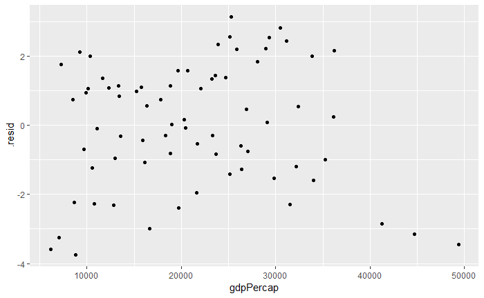

```r
ggplot(data = mod_au,mapping = aes( x=gdpPercap, y = .resid))+
  geom_point()
```

> - a boxplot of `y = .resid` from `mod_au` to get a residuals-boxplot (tip: use `x = “mod_au”`).

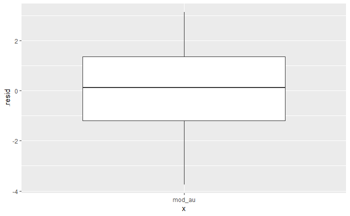

```r
ggplot(data = mod) +
  geom_boxplot(mapping = aes(y = .resid, x = "mod_au"))
```

> - create a qq-plot with `sample = .resid` from `mod_au`.

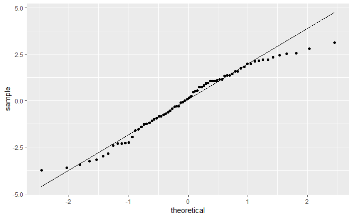

```r
ggplot(mod_au, mapping = aes(sample = .resid)) +
  stat_qq() +
  stat_qq_line()
```

> - based on your “Residuals:” section, these 3 plots and the sample size, is the model-assumption for the residuals (reasonably) fulfilled?
> 4. create a scatterplot of `x = gdpPercap` and `y = lifeExp` in `gapminder_6`, that you created in a). Also, add a best fit linear regression line `stat_smooth(method = lm)` that you in this case facet by variable country (you get six linear models).

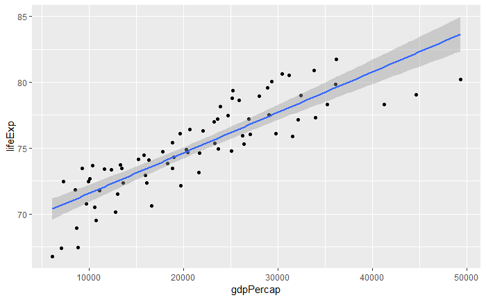

```r
ggplot(gapminder_6, mapping = aes(x = gdpPercap, y = lifeExp))+
  geom_point()+
  stat_smooth(method = lm)
```

> 5. obtain the quality-parameters of each of the 6 linear models (tip: for this purpose, use `gapminder_6` in a pipe-sentence together with `group_by`, `do`, `broom::glance` and the model `lm(lifeExp ~ gdpPercap, data=.)`. Save the output in `quality_6` and output it using `knitr::kable` with `format = “pandoc”, caption = "Quality of the linear modelling grouped by country", digits = 3`.

```r
quality_6 <- gapminder_6 %>%
  group_by(country)%>%
  do(broom::glance(lm(lifeExp ~ gdpPercap, data=.)))
knitr::kable(quality_6, format = "pandoc", caption = "Quality of the linear modelling grouped by country", digits = 3)
```

Quality of the linear modelling grouped by country

| country | r.squared | adj.r.squared | sigma | statistic | p.value | df | logLik | AIC | BIC | deviance | df.residual |
| --- | --- | --- | --- | --- | --- | --- | --- | --- | --- | --- | --- |
| Austria | 0.986 | 0.985 | 0.544 | 703.158 | 0 | 2 | -8.627 | 23.253 | 24.708 | 2.959 | 10 |
| Denmark | 0.974 | 0.972 | 0.373 | 379.799 | 0 | 2 | -4.098 | 14.195 | 15.650 | 1.391 | 10 |
| France | 0.992 | 0.992 | 0.392 | 1316.638 | 0 | 2 | -4.695 | 15.390 | 16.845 | 1.537 | 10 |
| Iceland | 0.960 | 0.956 | 0.633 | 241.661 | 0 | 2 | -10.441 | 26.883 | 28.338 | 4.004 | 10 |
| Norway | 0.984 | 0.983 | 0.318 | 628.774 | 0 | 2 | -2.188 | 10.377 | 11.832 | 1.012 | 10 |
| Sweden | 0.972 | 0.969 | 0.531 | 341.860 | 0 | 2 | -8.341 | 22.681 | 24.136 | 2.821 | 10 |

> - are the r-squared values for the six countries in your new table different, as compared with your previous r-squared value for the six countries in one group?

```r
r_sq <- mean(quality_6$r.squared)
adjusted_r_sq <- mean(quality_6$adj.r.squared)
r_sq
```

```
[1] 0.9781624
```

```r
adjusted_r_sq
```

```
[1] 0.9759786
```

```
In the code block above, the mean of the 6 different countries is calculated for both R-squared and
Adjusted
R-squared. For the previous calculations, where the original R-squared calculations were given for the
individual countries in one group, the results were the following:

Multiple R-squared:  0.7326,    Adjusted R-squared: 0.7288

According to this, it is evident that the values from the new table are different.
It is also worth noting, that all R-squared values (both adjusted and not) for the individual
countries
are close to the mean.
```

> 6. use a pipe to create `country_au` from your `gapminder_6` by using `group_by`, `do` and `augment` to add model residuals, predictions etc. for each data point (belonging to a country) for the model `lm(lifeExp ~ gdpPercap, data=.)`. Output `country_au`.

```r
country_au <- gapminder_6 %>%
  group_by(country)%>%
  do(augment(lm(lifeExp ~ gdpPercap, data=.)))
country_au
```

| country | lifeExp | gdpPercap | .fitted | .se.fit | .resid | .hat | .sigma | .cooksd | .std.resid |
| --- | --- | --- | --- | --- | --- | --- | --- | --- | --- |
| Austria | 66.800 | 6137.076 | 66.67344 | 0.28888145 | 0.126557271 | 0.28204342 | 0.5712116 | 1.480950e-02 | 0.27458471 |
| Austria | 67.480 | 8842.598 | 67.89209 | 0.25155012 | -0.412089125 | 0.21385811 | 0.5520506 | 9.930082e-02 | -0.85443499 |
| Austria | 69.540 | 10750.721 | 68.75156 | 0.22713151 | 0.788436174 | 0.17435382 | 0.4950813 | 2.686725e-01 | 1.59517337 |
| Austria | 70.140 | 12834.602 | 69.69021 | 0.20303602 | 0.449794812 | 0.13932301 | 0.5501300 | 6.430105e-02 | 0.89131802 |
| Austria | 70.630 | 16661.626 | 71.41401 | 0.16945583 | -0.784008885 | 0.09704870 | 0.5031145 | 1.236374e-01 | -1.51679594 |
| Austria | 72.170 | 19749.422 | 72.80484 | 0.15742853 | -0.634843246 | 0.08376133 | 0.5290434 | 6.795259e-02 | -1.21927181 |
| Austria | 73.180 | 21597.084 | 73.63708 | 0.15831105 | -0.457084193 | 0.08470307 | 0.5508168 | 3.569556e-02 | -0.87832155 |
| Austria | 74.940 | 23687.826 | 74.57882 | 0.16659399 | 0.361183976 | 0.09379838 | 0.5592550 | 2.517963e-02 | 0.69751636 |
| Austria | 76.040 | 27042.019 | 76.08964 | 0.19323733 | -0.049642930 | 0.12619982 | 0.5731038 | 6.883289e-04 | -0.09763144 |
| Austria | 77.510 | 29095.921 | 77.01478 | 0.21544419 | 0.495219269 | 0.15687230 | 0.5444651 | 9.145370e-02 | 0.99149195 |

[output cut: 62 more lines]

> - create these three plots:
> - a scatterplot graphic of`x = gdpPercap` and `y = .resid` from `country_au` to get a residuals-plot in six facets by country.

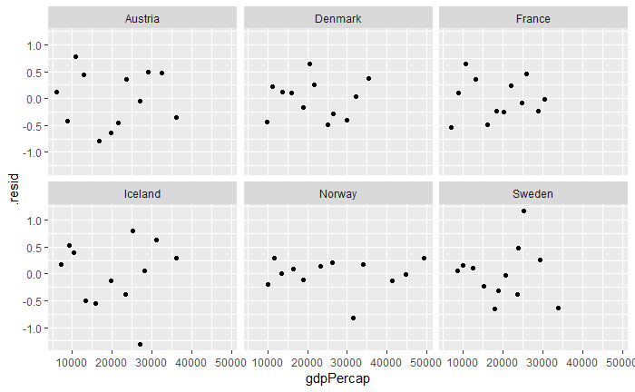

```r
ggplot(country_au, mapping = aes(x = gdpPercap, y = .resid)) +
  geom_point()+
  facet_wrap(~country_au$country)
```

> - a boxplot of `y = .resid` from `country_au` to get six residuals-boxplots in one plot (tip: use `x = country`).

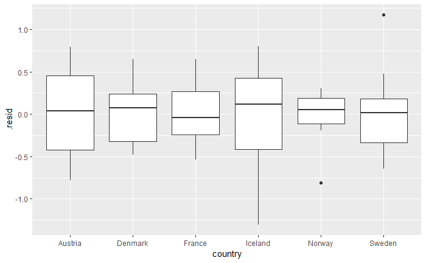

```r
ggplot(country_au) +
  geom_boxplot(mapping = aes(y = .resid, x = country))
```

> - a qq-plot with `sample = .resid` from `country_au` in six facets by country.

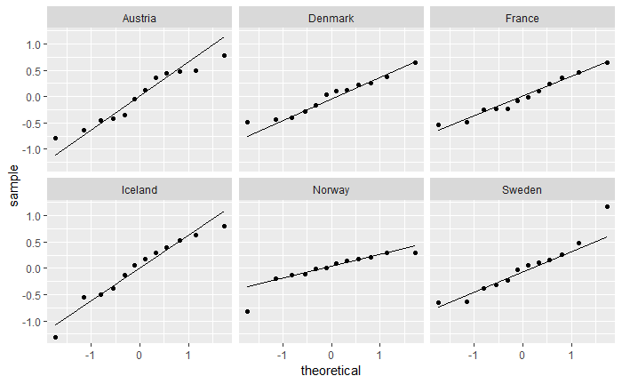

```r
ggplot(country_au, mapping = aes(sample = .resid))+
  stat_qq()+
  stat_qq_line()+
  facet_wrap(~country)
```

> - from your plots, try and make your best estimate of how well the assumptions for using the linear regression is fulfilled in our analysis of these six linear models for each country.

### Exercise 5

> 1. import the provided file of football data `results.csv` into the object `results` by using `read_csv` while you set the column format of the column date to `col_types = cols(date = col_date(format = "%Y-%m-%d"))`.
> - when imported, output `results`.

```r
results <- read_csv(file = "results.csv", col_types = cols(date = col_date(format = "%Y-%m-%d")))
results
```

| date | home_team | away_team | home_score | away_score | tournament | city | country | neutral |
| --- | --- | --- | --- | --- | --- | --- | --- | --- |
| 1872-11-30 | Scotland | England | 0 | 0 | Friendly | Glasgow | Scotland | FALSE |
| 1873-03-08 | England | Scotland | 4 | 2 | Friendly | London | England | FALSE |
| 1874-03-07 | Scotland | England | 2 | 1 | Friendly | Glasgow | Scotland | FALSE |
| 1875-03-06 | England | Scotland | 2 | 2 | Friendly | London | England | FALSE |
| 1876-03-04 | Scotland | England | 3 | 0 | Friendly | Glasgow | Scotland | FALSE |
| 1876-03-25 | Scotland | Wales | 4 | 0 | Friendly | Glasgow | Scotland | FALSE |
| 1877-03-03 | England | Scotland | 1 | 3 | Friendly | London | England | FALSE |
| 1877-03-05 | Wales | Scotland | 0 | 2 | Friendly | Wrexham | Wales | FALSE |
| 1878-03-02 | Scotland | England | 7 | 2 | Friendly | Glasgow | Scotland | FALSE |
| 1878-03-23 | Scotland | Wales | 9 | 0 | Friendly | Glasgow | Scotland | FALSE |

[output cut: 990 more lines]

> 2. save in `UEFI` a filter of `results` to only include:
> - `tournament` “UEFA Euro qualification”, “FIFA World Cup qualification”, and
> - `date` larger or equal than “1989-12-31”.
> - output `UEFI`.

```r
UEFI <- results %>%
  filter(tournament == "UEFA Euro qualification" | tournament == "FIFA World Cup qualification") %>%
  filter(date >= as.Date("1989-12-31"))
UEFI
```

| date | home_team | away_team | home_score | away_score | tournament | city | country | neutral |
| --- | --- | --- | --- | --- | --- | --- | --- | --- |
| 1990-05-30 | Iceland | Albania | 2 | 0 | UEFA Euro qualification | Reykjavík | Iceland | FALSE |
| 1990-09-05 | Iceland | France | 1 | 2 | UEFA Euro qualification | Reykjavík | Iceland | FALSE |
| 1990-09-12 | Faroe Islands | Austria | 1 | 0 | UEFA Euro qualification | Landskrona | Sweden | TRUE |
| 1990-09-12 | Finland | Portugal | 0 | 0 | UEFA Euro qualification | Helsinki | Finland | FALSE |
| 1990-09-12 | Northern Ireland | Yugoslavia | 0 | 2 | UEFA Euro qualification | Belfast | Northern Ireland | FALSE |
| 1990-09-12 | Russia | Norway | 2 | 0 | UEFA Euro qualification | Moscow | Soviet Union | FALSE |
| 1990-09-12 | Scotland | Romania | 2 | 1 | UEFA Euro qualification | Glasgow | Scotland | FALSE |
| 1990-09-12 | Switzerland | Bulgaria | 2 | 0 | UEFA Euro qualification | Geneva | Switzerland | FALSE |
| 1990-09-26 | Czechoslovakia | Iceland | 1 | 0 | UEFA Euro qualification | Košice | Czechoslovakia | FALSE |
| 1990-10-10 | Denmark | Faroe Islands | 4 | 1 | UEFA Euro qualification | Copenhagen | Denmark | FALSE |

[output cut: 990 more lines]

> 3. save in object `UEFI_home` a pipe of `UEFI` through a filter on:
> - `home_team` “Faroe Islands”, “Iceland”, “Denmark”, “Germany”, then a mutate:
> - to add the columns `score = home_score - away_score`, `team = home_team` and `type = "home"`.
> - output `UEFI_home`.

```r
teamfilter <- c("Faroe Islands", "Iceland", "Denmark", "Germany")
UEFI_home <- UEFI %>%
  filter(home_team %in% teamfilter)%>%
  mutate(score = home_score - away_score, team = home_team, type = "home")
UEFI_home
```

| date | home_team | away_team | home_score | away_score | tournament | city | country | neutral | score | team | type |
| --- | --- | --- | --- | --- | --- | --- | --- | --- | --- | --- | --- |
| 1990-05-30 | Iceland | Albania | 2 | 0 | UEFA Euro qualification | Reykjavík | Iceland | FALSE | 2 | Iceland | home |
| 1990-09-05 | Iceland | France | 1 | 2 | UEFA Euro qualification | Reykjavík | Iceland | FALSE | -1 | Iceland | home |
| 1990-09-12 | Faroe Islands | Austria | 1 | 0 | UEFA Euro qualification | Landskrona | Sweden | TRUE | 1 | Faroe Islands | home |
| 1990-10-10 | Denmark | Faroe Islands | 4 | 1 | UEFA Euro qualification | Copenhagen | Denmark | FALSE | 3 | Denmark | home |
| 1990-11-14 | Denmark | Yugoslavia | 0 | 2 | UEFA Euro qualification | Copenhagen | Denmark | FALSE | -2 | Denmark | home |
| 1991-05-01 | Germany | Belgium | 1 | 0 | UEFA Euro qualification | Hanover | Germany | FALSE | 1 | Germany | home |
| 1991-06-05 | Denmark | Austria | 2 | 1 | UEFA Euro qualification | Odense | Denmark | FALSE | 1 | Denmark | home |
| 1991-06-05 | Iceland | Czechoslovakia | 0 | 1 | UEFA Euro qualification | Reykjavík | Iceland | FALSE | -1 | Iceland | home |
| 1991-09-11 | Faroe Islands | Northern Ireland | 0 | 5 | UEFA Euro qualification | Landskrona | Sweden | TRUE | -5 | Faroe Islands | home |
| 1991-09-25 | Faroe Islands | Denmark | 0 | 4 | UEFA Euro qualification | Landskrona | Sweden | TRUE | -4 | Faroe Islands | home |

[output cut: 252 more lines]

> 4. save in object `UEFI_away` a pipe of `UEFI` through a filter on:
> - `away_team` “Faroe Islands”, “Iceland”, “Denmark”, “Germany”, then a mutate:
> - to add the columns `score = away_score - home_score`, `team = away_team` and `type = "away"`.
> - output `UEFI_away`.

```r
UEFI_away <- UEFI %>%
  filter(away_team %in% teamfilter) %>%
  mutate(score = away_score - home_score,team = away_team, type = "away")
UEFI_away
```

| date | home_team | away_team | home_score | away_score | tournament | city | country | neutral | score | team | type |
| --- | --- | --- | --- | --- | --- | --- | --- | --- | --- | --- | --- |
| 1990-09-26 | Czechoslovakia | Iceland | 1 | 0 | UEFA Euro qualification | Košice | Czechoslovakia | FALSE | -1 | Iceland | away |
| 1990-10-10 | Denmark | Faroe Islands | 4 | 1 | UEFA Euro qualification | Copenhagen | Denmark | FALSE | -3 | Faroe Islands | away |
| 1990-10-10 | Spain | Iceland | 2 | 1 | UEFA Euro qualification | Seville | Spain | FALSE | -1 | Iceland | away |
| 1990-10-17 | Northern Ireland | Denmark | 1 | 1 | UEFA Euro qualification | Belfast | Northern Ireland | FALSE | 0 | Denmark | away |
| 1990-10-31 | Luxembourg | Germany | 2 | 3 | UEFA Euro qualification | Luxembourg | Luxembourg | FALSE | 1 | Germany | away |
| 1991-05-01 | Northern Ireland | Faroe Islands | 1 | 1 | UEFA Euro qualification | Belfast | Northern Ireland | FALSE | 0 | Faroe Islands | away |
| 1991-05-01 | Yugoslavia | Denmark | 1 | 2 | UEFA Euro qualification | Belgrade | Yugoslavia | FALSE | 1 | Denmark | away |
| 1991-05-16 | Yugoslavia | Faroe Islands | 7 | 0 | UEFA Euro qualification | Belgrade | Yugoslavia | FALSE | -7 | Faroe Islands | away |
| 1991-05-22 | Austria | Faroe Islands | 3 | 0 | UEFA Euro qualification | Salzburg | Austria | FALSE | -3 | Faroe Islands | away |
| 1991-05-26 | Albania | Iceland | 1 | 0 | UEFA Euro qualification | Tirana | Albania | FALSE | -1 | Iceland | away |

[output cut: 252 more lines]

> 5. combine `UEFI_away` and `UEFI_home` into `UEFI_games` including all rows from both.
> - make a scatterplot of `x = date` and `y = score` in `UEFI_games` with smoothed linear curve (method = ‘lm’) and filter on variable `team`, so you get one scatterplot with a linear curve per team.

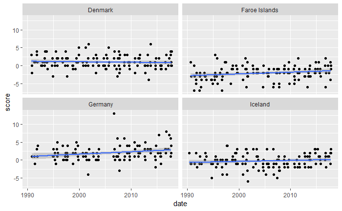

```r
UEFI_games <- rbind(UEFI_away, UEFI_home)
ggplot(UEFI_games, mapping = aes(x = date, y = score))+
  geom_point() +
  stat_smooth(method = lm)+
  facet_wrap(~team)
```

> - for each team, make your best judgement if these plots indicate any progress (dependence: none, weak, or strong) of the results with time, i.e. in the `score` variable versus the `date` variable.

```
If we look at the linear curve we can see that Icelande, Germany and Faroe Islands have slight
progress.
If we then look at the linear curve of Denmark's progress, we see that there is a slight curve
downwards indicating that they are doing worse
```

> 6. save in `home_away` a pipe of `UEFI_games` grouped by `team` and `type` to summarise: `n`, `loose (score < 0)`, `draw (score == 0)` and `win (score > 0)`, and the corresponding probabilities `p_lost`, `p_draw`, `p_win`. Your result should contain 9 columns: `team`, `type`, `n`, `loose`, `draw`, `win`, `p_lost`, `p_draw`, `p_win`and 8 rows of observations - two rows for each team. Output `home_away`.
> - at first glance (not doing any calculations nor tests), are the results `loose`, `draw` or `win` for Faroe Islands independent of the `type` variable (home and away)?
> - for this case, test the null hypothesis by using the chi-squared test for independence in two-way tables. Is the null hypothesis rejected?
> - at first glance (not doing any calculations nor tests), are the results `loose`, `draw` or `win` for Iceland independent of the `type` variable (home and away)?
> - for this case, test the null hypothesis by using the chi-squared test for independence in two-way tables. Is the null hypothesis rejected?